# Introduction

I'll be looking at a real-life dataset : [the Heart Disease Data Set from the UCI Machine Learning Repository](https://archive.ics.uci.edu/ml/datasets/Heart+Disease). This dataset comes from the famous Cleveland Clinic Foundation, which recorded information on various patient characteristics, including age and chest pain, to try to classify the presence of heart disease in an individual.

```python
import pandas as pd
import numpy as np
from sklearn.linear_model import LogisticRegression
from sklearn.metrics import confusion_matrix
from sklearn.model_selection import train_test_split
```

```python
heart = pd.read_csv("heart_disease.csv")
```

```python
heart.columns
```

```
Index(['Unnamed: 0', 'age', 'sex', 'cp', 'trestbps', 'chol', 'fbs', 'restecg',
       'thalach', 'exang', 'oldpeak', 'slope', 'ca', 'thal', 'present'],
      dtype='object')
```

# Exploring the Dataset

According to the [official page](https://archive.ics.uci.edu/ml/datasets/Heart+Disease), the present column is the binary outcome of interest. 0 encodes the absence of any heart disease, while 1 encodes the presence.

```python
print(heart.head(),heart.shape,sep='\n\n')
```

```
   Unnamed: 0  age  sex  cp  trestbps  chol  fbs  restecg  thalach  exang  \
0           1   63    1   1       145   233    1        2      150      0
1           2   67    1   4       160   286    0        2      108      1
2           3   67    1   4       120   229    0        2      129      1
3           4   37    1   3       130   250    0        0      187      0
4           5   41    0   2       130   204    0        2      172      0

   oldpeak  slope   ca thal  present
0      2.3      3  0.0  6.0        0
1      1.5      2  3.0  3.0        1
2      2.6      2  2.0  7.0        1
3      3.5      3  0.0  3.0        0
4      1.4      1  0.0  3.0        0

(303, 15)
```

```
array([[<AxesSubplot:title={'center':'present'}>]], dtype=object)
```

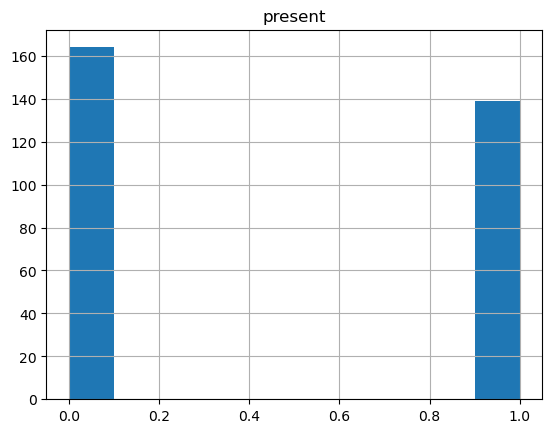

```python
heart.hist("present")
```

There's almost an equal number of cases and non-cases in the dataset.

```python
df=heart
df['ca']=df['ca'].apply(lambda e: e if e != '?' else 0).astype(float)
df['thal']=df['thal'].apply(lambda e: e if e != '?' else 0).astype(float)
df.drop(columns=['Unnamed: 0'],axis=1).groupby("present").mean()
```

| present | age | sex | cp | trestbps | chol | fbs | restecg | thalach | exang | oldpeak | slope | ca | thal |
| --- | --- | --- | --- | --- | --- | --- | --- | --- | --- | --- | --- | --- | --- |
| 0 | 52.585366 | 0.560976 | 2.792683 | 129.250000 | 242.640244 | 0.140244 | 0.835366 | 158.378049 | 0.140244 | 0.586585 | 1.408537 | 0.268293 | 3.774390 |
| 1 | 56.625899 | 0.820144 | 3.589928 | 134.568345 | 251.474820 | 0.158273 | 1.172662 | 139.258993 | 0.546763 | 1.574101 | 1.827338 | 1.129496 | 5.798561 |

Some columns have a small, but noticeable difference when stratified by predictors. Based on the differences and some knowledge about heart disease, these seem like good candidates for predictors:

- `age`
- `thalach` (maximum heart rate achieved)
- `restecg` (resting ECG)
- `ca` (number of vessels colored by fluoroscopy)

# Dividing The Data

I'll like to use an 80-20 split of the dataset for the training and test sets. The random state has also been set for reproducibility.

```python
X = df[["age", "thalach", "restecg", "ca"]]
y = df["present"]

# 70% for training set, 30% for test set
X_train, X_test, y_train, y_test = train_test_split(X, y, test_size = 0.2, random_state = 69420)
```

```python
print("Y_train: ", sum(y_train == 0))
print("Y_train: ", sum(y_train == 1))
print("Y_test: ", sum(y_test == 0))
print("Y_test: ", sum(y_test == 1))
```

```
Y_train:  125
Y_train:  117
Y_test:  39
Y_test:  22
```

I've confirmed above that there are both cases and non-cases in both the training and test sets

# Build The Model

```python
model = LogisticRegression()
model.fit(X_train, y_train)
```

```
LogisticRegression()
```

```python
acc = model.score(X_train, y_train)

predictions = model.predict(X_train)
tp = sum((predictions == 1) & (y_train == 1))
fp = sum((predictions == 1) & (y_train == 0))
tn = sum((predictions == 0) & (y_train == 0))
fn = sum((predictions == 0) & (y_train == 1))
sens = tp / (tp + fn)
spec = tn / (tn + fp)

print("Training Accuracy: ", acc)
print("Training Sensitivity: ", sens)
print("Training Specificity: ", spec)
```

```
Training Accuracy:  0.7603305785123967
Training Sensitivity:  0.6666666666666666
Training Specificity:  0.848
```

Overall the training accuracy was about 76%, the sensitivity was 67%, and the specificity was 85%. Based on these metrics, the model seems to perform better for non-cases.

# Interpreting The Model Coefficients

```python
coefs = ["age", "thalach", "restecg", "ca"]

# Checking in terms of log-odds
for coef, val  in zip(coefs, model.coef_[0]):
    print(coef, ":", round(val, 2))
```

```
age : -0.02
thalach : -0.04
restecg : 0.41
ca : 1.23
```

```python
# Checking in terms of odds
for coef, val  in zip(coefs, model.coef_[0]):
    print(coef, ":", round(np.exp(val), 2))
```

```
age : 0.98
thalach : 0.96
restecg : 1.5
ca : 3.41
```

# Final Model Evaluation

```python
# Checking the various metrics for the model (test set)
acc = model.score(X_test, y_test)

predictions = model.predict(X_test)
tp = sum((predictions == 1) & (y_test == 1))
fp = sum((predictions == 1) & (y_test == 0))
tn = sum((predictions == 0) & (y_test == 0))
fn = sum((predictions == 0) & (y_test == 1))
sens = tp / (tp + fn)
spec = tn / (tn + fp)

print("Test Accuracy: ", acc)
print("Test Sensitivity: ", sens)
print("Test Specificity: ", spec)
```

```
Test Accuracy:  0.7540983606557377
Test Sensitivity:  0.7272727272727273
Test Specificity:  0.7692307692307693
```

# Drawing Conclusions